# CHIRPS-short

Dario Lepke

25 6 2021

```r
library(ncdf4)
library(raster)
library(rgdal)
library(ggplot2)
library(assertthat)
library(lubridate)
```

## Quick overview

We open the file and inspect first infos.

### Variable

```r
chirps <- nc_open("../../data/raw/drought/chirps-v2.0.monthly.nc")
names(chirps$var)
```

```
## [1] "precip"
```

```r
ncatt_get(chirps, "precip", attname = "units")$value
```

```
## [1] "mm/month"
```

Variable of interest is precipitation over land measured in mm/month.

### Dimensions

```r
names(chirps$dim)
```

```
## [1] "longitude" "latitude"  "time"
```

#### Longitude and Latitude

```r
chirps_lon <- ncvar_get(chirps, "longitude")
range(chirps_lon)
```

```
## [1] -179.975  179.975
```

```r
chirps_lat <- ncvar_get(chirps, "latitude")
range(chirps_lat)
```

```
## [1] -49.975  49.975
```

#### Time

```r
chirps_time <- ncvar_get(chirps, "time")
range(chirps_time)
```

```
## [1]   366 15007
```

```r
ncatt_get(chirps, "time", attname = "units")$value
```

```
## [1] "days since 1980-1-1 0:0:0"
```

#### Summary CHIRPS raw

Precipitation is measured on a longitude/latidude grid ranging from **-180 to 180 and -50 to 50** respectively. The timestamps are given in **days since 1980-1-1**. Note the resolution is very high namely on a **0.05 x 0.05 grid**.

## Preprocessing data structure

The SST data ranges from 1880 until 2016 so we choose a **common time window of 1981 until 2016.** Subsetting the observations first will also reduce preprocessing cost in the following steps. We also set the orientation of the grid coordinates and choose the amazon basin as a geographical window and set a reference time that will be the same in both datasets.

```bash
# select common time period
cdo -z zip selyear,1981/2016 data/raw/drought/chirps-v2.0.monthly.nc data/interim/drought/chirps_selyear.nc

# change data orientation
cdo -z zip sellonlatbox,-180,180,-90,90 data/interim/drought/chirps_selyear.nc data/interim/drought/chirps_rearrangelonlatbox.nc

# select geographical window
cdo -z zip sellonlatbox,-72,-55,-9,0 data/interim/drought/chirps_rearrangelonlatbox.nc data/interim/drought/chirps_sellonlatbox.nc

# change reference time and units
cdo -z zip setreftime,1900-1-1,00:00:00,months data/interim/drought/chirps_sellonlatbox.nc data/interim/drought/chirps_setreftime.nc
```

## First Plot

We can load the data now

```r
chirps <- nc_open("../../data/interim/drought/chirps_setreftime.nc")
chirps_data<- ncvar_get(chirps, "precip")
```

```r
chirps_lon <- ncvar_get(chirps, "longitude")
chirps_lat <- ncvar_get(chirps, "latitude")
chirps_time <- ncvar_get(chirps, "time")
chirps_fill_val <- ncatt_get(chirps, "precip", "_FillValue")
chirps_data[chirps_data == chirps_fill_val$value] <- NA
```

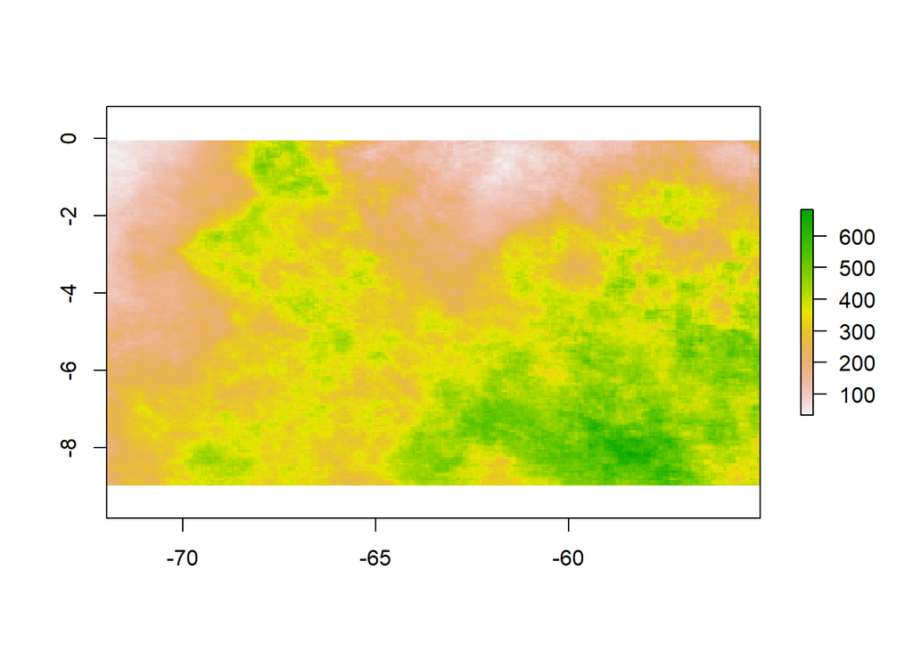

```r
set.seed(42)
m <- sample(dim(chirps_data)[3], 1)
slice <- chirps_data[,,m]
r <- raster(t(slice), xmn = min(chirps_lon), xmx = max(chirps_lon), ymn = min(chirps_lat), ymx = max(chirps_lat),
            crs = CRS("+proj=longlat +ellps=WGS84 +datum=WGS84 +no_defs+ towgs84=0,0,0"))
r <- flip(r, direction = "y")
plot(r)
```

## Appendix

```r
print(chirps)
```

```
## File ../../data/interim/drought/chirps_setreftime.nc (NC_FORMAT_NETCDF4):
##
##      1 variables (excluding dimension variables):
##         float precip[longitude,latitude,time]   (Chunking: [340,1,1])  (Compression: shuffle,level 1)
##             standard_name: convective precipitation rate
##             long_name: Climate Hazards group InfraRed Precipitation with Stations
##             units: mm/month
##             _FillValue: -9999
##             missing_value: -9999
##             time_step: month
##             geostatial_lat_min: -50
##             geostatial_lat_max: 50
##             geostatial_lon_min: -180
##             geostatial_lon_max: 180
##
##      3 dimensions:
##         time  Size:432   *** is unlimited ***
##             standard_name: time
##             units: months since 1900-1-1 00:00:00
##             calendar: gregorian
##             axis: T
##         longitude  Size:340
##             standard_name: longitude
##             long_name: longitude
##             units: degrees_east
##             axis: X
##         latitude  Size:180
##             standard_name: latitude
##             long_name: latitude
##             units: degrees_north
##             axis: Y
##
##     17 global attributes:
##         CDI: Climate Data Interface version 1.9.9rc1 (https://mpimet.mpg.de/cdi)
##         Conventions: CF-1.6
##         history: Fri Jun 25 20:00:48 2021: cdo -z zip setreftime,1900-1-1,00:00:00,months data/interim/drought/chirps_sellonlatbox.nc data/interim/drought/chirps_setreftime.nc
## Fri Jun 25 19:55:16 2021: cdo -z zip sellonlatbox,-72,-55,-9,0 data/interim/drought/chirps_rearrangelonlatbox.nc data/interim/drought/chirps_sellonlatbox.nc
## Fri Jun 25 19:47:03 2021: cdo -z zip sellonlatbox,-180,180,-90,90 data/interim/drought/chirps_selyear.nc data/interim/drought/chirps_rearrangelonlatbox.nc
## Fri Jun 25 14:44:14 2021: cdo -z zip selyear,1981/2016 data/raw/drought/chirps-v2.0.monthly.nc data/interim/drought/chirps_selyear.nc
## created by Climate Hazards Group
##         institution: Climate Hazards Group.  University of California at Santa Barbara
##         title: CHIRPS Version 2.0
##         version: Version 2.0
##         date_created: 2021-03-16
##         creator_name: Pete Peterson
##         creator_email: pete@geog.ucsb.edu
##         documentation: http://pubs.usgs.gov/ds/832/
##         reference: Funk, C.C., Peterson, P.J., Landsfeld, M.F., Pedreros, D.H., Verdin, J.P., Rowland, J.D., Romero, B.E., Husak, G.J., Michaelsen, J.C., and Verdin, A.P., 2014, A quasi-global precipitation time series for drought monitoring: U.S. Geological Survey Data Series 832, 4 p., http://d…
##         comments:  time variable denotes the first day of the given month.
##         acknowledgements: The Climate Hazards Group InfraRed Precipitation with Stations development process was carried out through U.S. Geological Survey (USGS) cooperative agreement #G09AC000001 "Monitoring and Forecasting Climate, Water and Land Use for Food Production in the Developing World…
##         ftp_url: ftp://chg-ftpout.geog.ucsb.edu/pub/org/chg/products/CHIRPS-latest/
##         website: http://chg.geog.ucsb.edu/data/chirps/index.html
##         faq: http://chg-wiki.geog.ucsb.edu/wiki/CHIRPS_FAQ
##         CDO: Climate Data Operators version 1.9.9rc1 (https://mpimet.mpg.de/cdo)
```

```r
nc_close(chirps)
```

```r
knitr::knit_exit()
```